# Basic data analysis

## The Gambia data set

In the following, we will use the Egambia data set included in the package. The data set has been generated by Maertzdorf et al. [-@maertzdorf2011functional] and has the GEO ID GSE28623. The data is already background corrected and normalized, so we can proceed with a differential gene expression analysis. Note that only a bit over 5000 genes from the original set of over 45000 probes is included.

```r
library(limma)
library(tmod)
data(Egambia)
design <- cbind(Intercept=rep(1, 30), TB=rep(c(0,1), each= 15))
E <- as.matrix(Egambia[,-c(1:3)])
fit <- eBayes( lmFit(E, design))
tt <- topTable(fit, coef=2, number=Inf,
  genelist=Egambia[,1:3] )

head(tt, 10)
```

```
##       GENE_SYMBOL
## 4178       FAM20A
## 20799      FCGR1B
## 4122        BATF2
## 23567     ANKRD22
## 20498       SEPT4
## 20360       CD274
## 2513         AIM2
## 24032      GOLSYN
## 1337         ETV7
## 467      SERPING1
##                                                           GENE_NAME     EG
## 4178                  family with sequence similarity 20, member A"  54757
## 20799        Fc fragment of IgG, high affinity Ib, receptor (CD64)"   2210
## 4122          basic leucine zipper transcription factor, ATF-like 2 116071
```

[output cut: 18 more lines]

OK, we see some of the genes known to be prominent in the human host response to TB. We can display one of these using tmod's showGene function (it's just a boxplot combined with a beeswarm, nothing special):

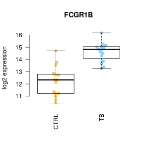

```r
group <- rep( c("CTRL", "TB"), each=15)
showGene(E["20799",], group,
  main=Egambia["20799", "GENE_SYMBOL"])
```

Fine, but what about the modules?

## Transcriptional module analysis

There are two main functions in tmod to understand which modules are significantly enriched<sup>[If</sup> you work with limma, there are other, more efficient and simpler to use functions. See “Working with limma” below. ]

The first one, tmodHGtest, is simply a hypergeometric test on two groups of genes: 'foreground' (fg), or the list of differentially expressed genes, and 'background' (bg) – the gene universe, i.e., all genes present in the analysis. The gene identifiers used currently by tmod are HGNC identifiers, and we will use the GENE_SYMBOL field from the Egambia data set.

```r
fg <- tt$GENE_SYMBOL[tt$adj.P.Val < 0.05 & abs( tt$logFC ) > 1]
res <- tmodHGtest(fg=fg, bg=tt$GENE_SYMBOL)
res
```

```
##                  ID                                            Title b  B
## LI.M112.0 LI.M112.0                        complement activation (I) 4 11
## LI.M11.0   LI.M11.0                       enriched in monocytes (II) 4 20
## LI.M75       LI.M75                          antiviral IFN signature 3 10
## LI.S4         LI.S4                       Monocyte surface signature 3 10
## LI.S5         LI.S5                             DC surface signature 4 34
## LI.M165     LI.M165       enriched in activated dendritic cells (II) 3 19
## LI.M4.3     LI.M4.3 myeloid cell enriched receptors and transporters 2  5
## LI.M16       LI.M16                   TLR and inflammatory signaling 2  5
##            n    N        E      P.Value    adj.P.Val
## LI.M112.0 47 4826 37.33849 2.480096e-06 0.0008581134
## LI.M11.0  47 4826 20.53617 3.414323e-05 0.0059067783
## LI.M75    47 4826 30.80426 9.906126e-05 0.0085687989
## LI.S4     47 4826 30.80426 9.906126e-05 0.0085687989
## LI.S5     47 4826 12.08010 2.957367e-04 0.0204649814
## LI.M165   47 4826 16.21277 7.521410e-04 0.0394125446
## LI.M4.3   47 4826 41.07234 9.112727e-04 0.0394125446
## LI.M16    47 4826 41.07234 9.112727e-04 0.0394125446
```

The columns in the above table contain the following:

- **ID** The module ID. IDs starting with “LI” come from Li et al. [@li2013molecular], while IDs starting with “DC” have been defined by Chaussabel et al. [@chaussabel2008modular].
- **Title** The module description
- **b** Number of genes from the given module in the fg set
- **B** Number of genes from the module in the bg set
- **n** Size of the fg set
- **N** Size of the bg set
- **E** Enrichment, calcualted as (b/n)/(B/N)
- **P.Value** P-value from the hypergeometric test
- **adj.P.Val** P-value adjusted for multiple testing using the Benjamini-Hochberg correction

Well, IFN signature in TB is well known. However, the numbers of genes are not high: n is the size of the foreground, and b the number of genes in fg that belong to the given module. N and B are the respective totals – size of bg+fg and number of genes that belong to the module that are found in this totality of the analysed genes. If we were using the full Gambia data set (with all its genes), we would have a different situation.

Another approach is to sort all the genes (for example, by the respective p-value) and perform a U-test on the ranks of (i) genes belonging to the module and (ii) genes that do not belong to the module. This is a bit slower, but often works even in the case if the power of the statistical test for differential expression is low. That is, even if only a few genes or none at all are significant at acceptable thresholds, sorting them by the p-value or another similar metric can nonetheless allow to get meaningful enrichments<sup>[The</sup> rationale is that the non-significant p-values are not associated with the test that we are actually performing, but merely used to sort the gene list. Thus, it does not matter whether they are significant or not.].

Moreover, we do not need to set arbitrary thresholds, like p-value or logFC cutoff.

```r
l    <- tt$GENE_SYMBOL
res2 <- tmodUtest(l)
head(res2)
```

```
##                ID                               Title      U  N1       AUC
## LI.M37.0 LI.M37.0 immune activation - generic cluster 352659 100 0.7462103
## LI.M37.1 LI.M37.1         enriched in neutrophils (I)  50280  12 0.8703781
## LI.S4       LI.S4          Monocyte surface signature  43220  10 0.8974252
## LI.M75     LI.M75             antiviral IFN signature  42996  10 0.8927741
## LI.M11.0 LI.M11.0          enriched in monocytes (II)  74652  20 0.7766542
## LI.M67     LI.M67           activated dendritic cells  28095   6 0.9714730
##               P.Value    adj.P.Val
## LI.M37.0 1.597067e-17 5.525852e-15
## LI.M37.1 4.530577e-06 6.569127e-04
## LI.S4    6.853638e-06 6.569127e-04
## LI.M75   8.632649e-06 6.569127e-04
## LI.M11.0 9.492958e-06 6.569127e-04
## LI.M67   3.200305e-05 1.811391e-03
```

```r
nrow(res2)
```

```
## [1] 25
```

This list makes a lot of sense, and also is more stable than the other one: it does not depend on modules that contain just a few genes. Since the statistics is different, the b, B, n, N and E columns in the output have been replaced by the following:

- **U** The Mann-Whitney U statistics
- **N1** Number of genes in the module
- **AUC** Area under curve – a measure of the effect size

There are two tests in tmod which both operate on an ordered list of genes: `tmodUtest` and `tmodCERNOtest`. The U test is simple, however has two main issues. Firstly, it detects enrichments as well as depletions – that is, modules which are enriched at the bottom of the list (e.g. modules which are never, ever regulated in a particular comparison) will be detected as well. This is often undesirable. Secondly, large modules will be reported as significant even if the actual effect size (i.e., AUC) is modest or very small, just because of the sheer number of genes in a module. Unfortunately, also the reverse is true: modules with a small number of genes, even if they consist of highly up- or down-regulated genes from the top of the list will not be detected.

The CERNO test, described by Yamaguchi et al. [@yamaguchi2008ifn], is based on Fisher's method of combining probabilities. In summary, for a given module, the ranks of genes from the module are logarithmized, summed and multiplied by -2:

\[f_{CERNO}=-2 \cdot \sum_{i = 1}^{N} \ln{\frac{R_i}{N_{tot}}}\]

This statitic has the \(\chi^2\) distribution with \(2\cdot N\) degrees of freedom, where \(N\) is the number of genes in a given module and \(N_{tot}\) is the total number of genes [@yamaguchi2008ifn].

The CERNO test is actually much more practical than the U test for most purposes.

```r
l    <- tt$GENE_SYMBOL
res2 <- tmodCERNOtest(l)
head( res2 )
```

```
##                  ID                               Title     cerno  N1
## LI.M37.0   LI.M37.0 immune activation - generic cluster 426.35781 100
## LI.M11.0   LI.M11.0          enriched in monocytes (II) 113.80864  20
## LI.S4         LI.S4          Monocyte surface signature  76.37298  10
## LI.M112.0 LI.M112.0           complement activation (I)  73.67987  11
## LI.M75       LI.M75             antiviral IFN signature  65.29854  10
## LI.M16       LI.M16      TLR and inflammatory signaling  46.33475   5
##                 AUC      cES      P.Value    adj.P.Val
## LI.M37.0  0.7462103 2.131789 1.824844e-18 6.313962e-16
## LI.M11.0  0.7766542 2.845216 5.255069e-09 9.091270e-07
## LI.S4     0.8974252 3.818649 1.606057e-08 1.852319e-06
## LI.M112.0 0.8455773 3.349085 1.722322e-07 1.489809e-05
## LI.M75    0.8927741 3.264927 1.045914e-06 7.192190e-05
## LI.M16    0.9790500 4.633475 1.247201e-06 7.192190e-05
```

Here, the results are similar, however CERNO test was able to detect another module – “TLR and inflammatory signaling”. Although only 5 genes are in this module (which is why U test could not detect it), the genes are all on the top of the list of the differentially regulated genes.

Let us now investigate in more detail the module LI.M75, the antiviral interferon signature. We can use the `evidencePlot` function to see how the module is enriched in the list `l`.

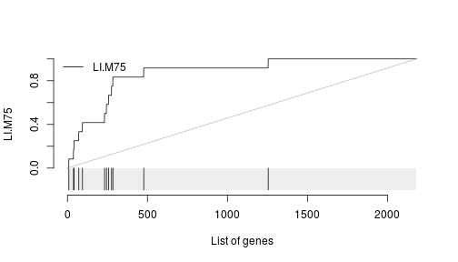

```r
evidencePlot(l, "LI.M75")
```

In essence, this is a receiver-operator characteristic (ROC) curve, and the area under the curve (AUC) is related to the U-statistic, from which the P-value in the tmodUtest is calculated, as \(\text{AUC}=\frac{U}{n_1\cdot n_2}\). Both the U statistic and the AUC are reported. Moreover, the AUC can be used to calculate effect size according to the Wendt's formula[@wendt1972dealing] for rank-biserial correlation coefficient:

\[r=1-\frac{2\cdot U}{n_1\cdot n_2} = 1 - 2\cdot\text{AUC}\]

In the above diagram, we see that nine out of the 10 genes that belong to the LI.M75 module and which are present in the Egambia data set are ranked among the top 1000 genes (as sorted by p-value).

# Working with multiple sets of comparisons

## Working with limma

Given the popularity of the limma package, tmod includes functions to easily integrate with limma. In fact, if you fit a design / contrast with limma function lmFit and calculate the p-values with eBayes(), you can directly use the resulting object in tmodLimmaTest and tmodLimmaDecideTests<sup>[The</sup> function tmodLimmaDecideTests is described in the next section].

```r
res.l <- tmodLimmaTest(fit, Egambia$GENE_SYMBOL)
length(res.l)
```

```
## [1] 2
```

```r
names(res.l)
```

```
## [1] "Intercept" "TB"
```

```r
head(res.l$TB)
```

```
##                  ID                               Title     cerno  N1
## LI.M37.0   LI.M37.0 immune activation - generic cluster 414.27395 100
## LI.M11.0   LI.M11.0          enriched in monocytes (II) 105.61794  20
## LI.M112.0 LI.M112.0           complement activation (I)  75.62229  11
## LI.S4         LI.S4          Monocyte surface signature  69.97439  10
## LI.M75       LI.M75             antiviral IFN signature  66.10214  10
## LI.M67       LI.M67           activated dendritic cells  50.35750   6
##                 AUC      cES      P.Value    adj.P.Val
## LI.M37.0  0.7255121 2.071370 4.568772e-17 1.580795e-14
## LI.M11.0  0.7862464 2.640449 7.921155e-08 9.671792e-06
## LI.M112.0 0.8667988 3.437377 8.385947e-08 9.671792e-06
## LI.S4     0.8836794 3.498719 1.838992e-07 1.590728e-05
## LI.M75    0.8645349 3.305107 7.780282e-07 5.383955e-05
## LI.M67    0.9712310 4.196458 1.208877e-06 6.971189e-05
```

The tmodLimmaTest function uses coefficients and p-values from the limma object to order the genes. By default, the genes are ordered by MSD (Minimum Significant Difference), rather than p-value or log fold change.

The MSD is defined as follows:

\[ \text{MSD} = \begin{cases} CI.L & \text{if logFC} > 0\ -CI.R & \text{if logFC} < 0\\ \end{cases} \]

The idea behind MSD is as follows. Ordering genes by decreasing absolute log fold change will include on the top of the list some genes close to background, for which log fold changes are grand, but so are the errors and confidence intervals, just because measuring genes with low expression is loaded with errors. Ordering genes by decreasing absolute log fold change should be avoided.

On the other hand, in a list ordered by p-values, many of the genes on the top of the list will have strong signals and high expression, which results in better statistical power and ultimately with lower p-values – even though the actual fold changes might not be very impressive.

However, by using MSD and using the boundary of the confidence interval to order the genes, the genes on the top of the list are those for which we can *confidently* that the actual log fold change is large. That is because the 95% confidence intervals tells us that in 95% cases, the real log fold change will be anywhere within that interval. Using its bountary closer to the x-axis (zero log fold change), we say that in 95% of the cases the log fold change will have this or larger magnitude (hence, “minimal significant difference”).

This can be visualized as follows, using the drop-in replacement for limma's topTable function, tmodLimmaTopTable, which calculates msd as well as confidence intervals. We will consider only genes with positive log fold changes and we will show top 50 genes as ordered by the three different measures:

```r
plotCI <- function(x, ci.l, ci.r, title="") {
  n <- length(x)
  plot(x,
    ylab="logFC", xlab="Index",
    pch=19, ylim=c( min(x-ci.l), max(x+ci.r)),
    main=title)
  segments(1:n, ci.l, 1:n, ci.r, lwd=5, col="#33333333")
}

par(mfrow=c(1,3))

x <- tmodLimmaTopTable(fit, coef="TB")
print(head(x))
```

```
##      logFC.TB     msd.TB     ciL.TB    ciR.TB    qval.TB
## 1  0.02819016 -0.7277810 -0.7277810 0.7841613 0.99538447
## 2  1.52416640  0.7280616  0.7280616 2.3202712 0.04393162
## 3  0.07888294 -0.8174289 -0.8174289 0.9751948 0.99504430
## 4  0.15321399 -0.8055162 -0.8055162 1.1119442 0.99504430
## 5 -0.23501607 -0.5368429 -1.0068750 0.5368429 0.99504430
## 6 -0.31952987 -0.8399144 -1.4789741 0.8399144 0.99504430
```

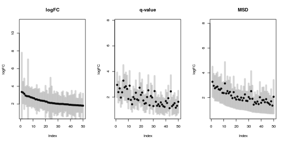

```r
x <- x[ x$logFC.TB > 0, ] # only to simplify the output!
x2 <- x[ order(abs(x$logFC.TB), decreasing=T),][1:50,]
plotCI(x2$logFC.TB, x2$ciL.TB, x2$ciR.TB, "logFC")

x2 <- x[ order(x$qval.TB),][1:50,]
plotCI(x2$logFC.TB, x2$ciL.TB, x2$ciR.TB, "q-value")

x2 <- x[ order(x$msd.TB, decreasing=T),][1:50,]
plotCI(x2$logFC.TB, x2$ciL.TB, x2$ciR.TB, "MSD")
```

Black dots are logFCs, and grey bars denote 95% confidence intervals. On the left panel, the top 50 genes ordered by the fold change include several genes with broad confidence intervals, which, despite having a large log fold change, are not significantly up- or down-regulated.

On the middle panel the genes are ordered by p-value. It is clear that the log fold changes of the genes vary considerably, and that the list includes genes which are more and less strongly regulated in TB.

The third panel shows genes ordered by decreasing MSD. There is less variation in the logFC than on the second panel, but at the same time the fallacy of the first panel is avoided. MSD is a compromise between considering the effect size and the statistical significance.

What about enrichments?

```r
x <- tmodLimmaTopTable(fit, coef="TB", genelist=Egambia[,1:3])
x.lfc  <- x[ order(abs(x$logFC.TB), decreasing=T),]
x.qval <- x[ order(x$qval.TB),]
x.msd  <- x[ order(x$msd.TB, decreasing=T),]

head(tmodCERNOtest(x.lfc$GENE_SYMBOL))
```

```
##                  ID                                      Title     cerno
## LI.M37.0   LI.M37.0        immune activation - generic cluster 381.20058
## LI.M112.0 LI.M112.0                  complement activation (I)  67.57425
## LI.M75       LI.M75                    antiviral IFN signature  59.49036
## LI.S4         LI.S4                 Monocyte surface signature  58.93059
## LI.M67       LI.M67                  activated dendritic cells  44.54543
## LI.M165     LI.M165 enriched in activated dendritic cells (II)  84.06285
##            N1       AUC      cES      P.Value    adj.P.Val
## LI.M37.0  100 0.7345239 1.906003 1.990299e-13 6.886434e-11
## LI.M112.0  11 0.8340036 3.071557 1.583945e-06 2.740225e-04
## LI.M75     10 0.8714493 2.974518 8.537502e-06 8.529686e-04
## LI.S4      10 0.8759759 2.946529 1.041171e-05 8.529686e-04
## LI.M67      6 0.9406639 3.712119 1.232614e-05 8.529686e-04
## LI.M165    19 0.7057362 2.212180 2.482939e-05 1.431828e-03
```

```r
head(tmodCERNOtest(x.qval$GENE_SYMBOL))
```

```
##                  ID                               Title     cerno  N1
## LI.M37.0   LI.M37.0 immune activation - generic cluster 427.03180 100
## LI.M11.0   LI.M11.0          enriched in monocytes (II) 114.85395  20
## LI.S4         LI.S4          Monocyte surface signature  77.27812  10
## LI.M112.0 LI.M112.0           complement activation (I)  74.30410  11
## LI.M75       LI.M75             antiviral IFN signature  65.41723  10
## LI.M16       LI.M16      TLR and inflammatory signaling  46.32281   5
##                 AUC      cES      P.Value    adj.P.Val
## LI.M37.0  0.7523212 2.135159 1.521279e-18 5.263625e-16
## LI.M11.0  0.7910112 2.871349 3.691442e-09 6.386194e-07
## LI.S4     0.9164037 3.863906 1.131929e-08 1.305491e-06
## LI.M112.0 0.8595676 3.377459 1.367620e-07 1.182991e-05
## LI.M75    0.8932932 3.270861 1.001270e-06 6.928788e-05
## LI.M16    0.9790085 4.632281 1.253436e-06 7.228150e-05
```

```r
head(tmodCERNOtest(x.msd$GENE_SYMBOL))
```

```
##                  ID                               Title     cerno  N1
## LI.M37.0   LI.M37.0 immune activation - generic cluster 414.27395 100
## LI.M11.0   LI.M11.0          enriched in monocytes (II) 105.61794  20
## LI.M112.0 LI.M112.0           complement activation (I)  75.62229  11
## LI.S4         LI.S4          Monocyte surface signature  69.97439  10
## LI.M75       LI.M75             antiviral IFN signature  66.10214  10
## LI.M67       LI.M67           activated dendritic cells  50.35750   6
##                 AUC      cES      P.Value    adj.P.Val
## LI.M37.0  0.7255121 2.071370 4.568772e-17 1.580795e-14
## LI.M11.0  0.7862464 2.640449 7.921155e-08 9.671792e-06
## LI.M112.0 0.8667988 3.437377 8.385947e-08 9.671792e-06
## LI.S4     0.8836794 3.498719 1.838992e-07 1.590728e-05
## LI.M75    0.8645349 3.305107 7.780282e-07 5.383955e-05
## LI.M67    0.9712310 4.196458 1.208877e-06 6.971189e-05
```

In this case, the results of p-value and msd-ordering are very similar.

## Comparing tests across experimental conditions

In the above example with the Gambian data set there were only two coefficients calculated in limma, the intercept and the TB. However, often there are several coefficients or contrasts which are analysed simultaneously, for example different experimental conditions or different time points. tmod includes several functions which make it easy to visualize such sets of enrichments.

The object res.l created above using the tmod function tmodLimmaTest is a list of tmod results. Any such list can be directly passed on to functions tmodSummary and tmodPanelPlot, as long as each element of the list has been created with tmodCERNOtest or a similar function. tmodSummary creates a table summarizing module information in each of the comparisons made. The values for modules which are not found in a result object (i.e., which were not found to be significantly enriched in a given comparison) are shown as NA's:

```r
head(tmodSummary(res.l), 5)
```

```
##                  ID                         Title AUC.Intercept
## LI.M11.0   LI.M11.0    enriched in monocytes (II)     0.8145651
## LI.M112.0 LI.M112.0     complement activation (I)            NA
## LI.M118.0 LI.M118.0    enriched in monocytes (IV)            NA
## LI.M124     LI.M124 enriched in membrane proteins     0.8807517
## LI.M127     LI.M127    type I interferon response            NA
##            q.Intercept    AUC.TB         q.TB
## LI.M11.0  0.0001137611 0.7862464 9.671792e-06
## LI.M112.0           NA 0.8667988 9.671792e-06
## LI.M118.0           NA 0.8377967 2.850219e-03
## LI.M124   0.0114869572        NA           NA
## LI.M127             NA 0.9448247 1.043621e-02
```

We can neatly visualize the above information on a heatmap-like representation:

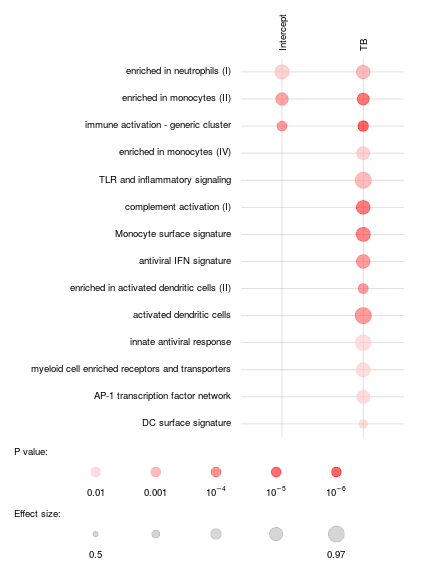

```r
tmodPanelPlot(res.l, text.cex=0.8)
```

The sizes of the red blobs on the figure correspond to the effect size, that is, the AUC, while the intensity of the color reflects the q-value from the module enrichment test. We can see that also the intercept term is enriched for genes found in monocytes and neutrophils. Note that by default, tmodPanelPlot only shows enrichments with p < 0.01, hence a slight difference from the tmodSummary output.

The function tmodPanelPlot has many optional arguments for customization, including options for label sizes, p value thresholds and custom functions for plotting the test results instead of just red blobs.

It is often of interest to see which enriched modules go up, and which go down? Specifically, we would like to see, for each module, how many genes are up-, and how many genes are down-regulated. tmodPanelPlot takes an optional argument, pie, which contains information on significantly regulated genes in modules. We can conveniently generate it from a limma linear fit object with the tmodLimmaDecideTests function:

```r
pie <- tmodLimmaDecideTests(fit, genes=Egambia$GENE_SYMBOL)
head(pie$TB[ order( pie$TB[,"Up"], decreasing=T), ])
```

```
##           Down Zero Up
## DC.M3.4      0   11  9
## DC.M4.2      0   16  7
## LI.M11.0     0   16  4
## LI.M37.0     0  110  4
## LI.M112.0    0    9  4
## LI.M165      0   24  4
```

```r
data(tmod)
tmod$MODULES["DC.M3.4",]
```

```
##              ID      Title Category Annotated
## DC.M3.4 DC.M3.4 Interferon    DC.M3       Yes
##                                                                                URL
## DC.M3.4 http://www.biir.net/public_wikis/module_annotation/V2_Trial_8_Modules_M3.4
##                       Source SourceID original.ID  B
## DC.M3.4 http://www.biir.net/       DC        M3.4 53
```

The pie object is a list. Each element of the list corresponds to one coefficient and is a data frame with the columns “Down”, “Zero” and “Up” (in that order). We can use this information in tmodPanelPlot:

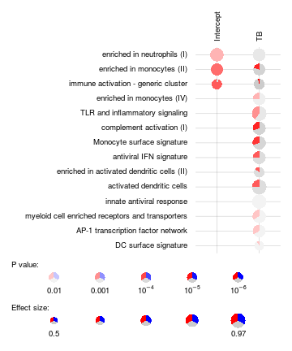

```r
tmodPanelPlot(res.l, pie=pie, text.cex=0.8)
```

A rug-like plot can be also generated:

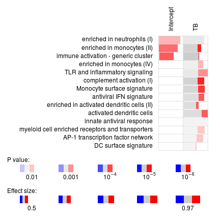

```r
tmodPanelPlot(res.l,
  pie=pie, pie.style="rug",
  grid="between")
```

There is also a more general function, tmodDecideTests that also produces a tmodPanelPlot-compatible object, a list of data frames with gene counts. However, instead of taking a limma object, it requires (i) a gene name, (ii) a vector or a matrix of log fold changes, and (iii) a vector or a matrix of p-values. We can replicate the result of tmodLimmaDecideTests above with the following commands:

```r
tt.I <-
  topTable(fit, coef="Intercept", number=Inf, sort.by="n")
tt.TB <- topTable(fit, coef="TB", number=Inf, sort.by="n")
pie2 <- tmodDecideTests(Egambia$GENE_SYMBOL,
  lfc=cbind(tt.I$logFC, tt.TB$logFC),
  pval=cbind(tt.I$adj.P.Val, tt.TB$adj.P.Val))
identical(pie[[1]], pie2[[1]])
```

```
## [1] TRUE
```

## Using other sets of modules

By default, tmod uses the modules published by Li et al. @li2013molecular. A second set of modules was published by Chaussabel et al. @chaussabel2008modular; new module definitions were described by Banchereau et al. [@banchereau2012host] and can be found on a public website<sup>[http://www.biir.net/public_wikis/module_annotation/G2_Trial_8_Modules].</sup>

Depending on the `mset` parameter to the test functions, either the LI or DC sets are used, or both, if the `mset=all` has been specified.

```r
l    <- tt$GENE_SYMBOL
res2 <- tmodUtest(l, mset="all")
head( res2 )
```

```
##                ID                               Title      U  N1       AUC
## LI.M37.0 LI.M37.0 immune activation - generic cluster 352659 100 0.7462103
## DC.M4.2   DC.M4.2                        Inflammation  91352  20 0.9503953
## DC.M1.2   DC.M1.2                          Interferon  73612  17 0.9004196
## DC.M3.2   DC.M3.2                        Inflammation  96366  24 0.8361620
## DC.M5.15 DC.M5.15                         Neutrophils  65289  16 0.8483498
## DC.M7.29 DC.M7.29                        Undetermined  77738  20 0.8087599
##               P.Value    adj.P.Val
## LI.M37.0 1.597067e-17 9.678227e-15
## DC.M4.2  1.674762e-12 5.074530e-10
## DC.M1.2  5.703006e-09 9.623646e-07
## DC.M3.2  6.352241e-09 9.623646e-07
## DC.M5.15 7.240084e-07 8.774982e-05
## DC.M7.29 9.084521e-07 9.175366e-05
```

As you can see, the information contained in both module sets is partially redundant.

# Functional multivariate analysis

Transcriptional modules can help to understand the biological meaning of the calculated multivariate transformations. For example, consider a principal component analysis (PCA), visualised using the pca3d package [@pca3d]:

```r
library(pca3d)
mypal <- c("#E69F00", "#56B4E9")
pca <- prcomp(t(E), scale.=TRUE)
par(mfrow=c(1, 2))
l<-pca2d(pca, group=group,
  palette=mypal)
```

```
##
## Legend:
## -------------------------
##   group:   color,   shape
## -------------------------
##    CTRL: #56B4E9,      16
##      TB: #E69F00,      17
```

```r
cols <- as.character(l$colors)
legend("topleft", as.character(l$groups),
       pch=l$shapes,
       col=cols, bty="n")
l<-pca2d(pca, group=group, components=3:4,
  palette=mypal)
```

```
##
## Legend:
## -------------------------
##   group:   color,   shape
## -------------------------
##    CTRL: #56B4E9,      16
##      TB: #E69F00,      17
```

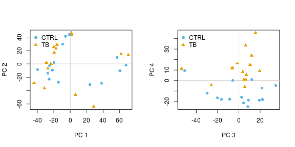

```r
legend("topleft", as.character(l$groups),
       pch=l$shapes,
       col=cols, bty="n")
```

The fourth component looks really interesting. Does it correspond to the modules which we have found before? Each principal component is, after all, a linear combination of gene expression values multiplied by weights (or scores) which are constant for a given component. The *i*-th principal component for sample *j* is given by

\[PC_{i,j} = \sum_{k} w_{i,k} \cdot x_{k,j}\]

where \(k\) is the index of the variables (genes in our case), \(w_{i,k}\) is the weight associated with the \(i\)-th component and the \(k\)-th variable (gene), and \(x_{k,j}\) is the value of the variable \(k\) for the sample \(j\); that is, the gene expression of gene \(k\) in the sample \(j\). Genes influence the position of a sample along a given component the more the larger their absolute weight for that component.

For example, on the right-hand figure above, we see that samples which were taken from TB patients have a high value of the principal component 4; the opposite is true for the healthy controls. The genes that allow us to differentiate between these two groups will have very large, positive weights for genes highly expressed in TB patients, and very large, negative weights for genes which are highly expressed in NID, but not TB.

We can sort the genes by their weight in the given component, since the weights are stored in the pca object in the “rotation” slot, and use the tmodUtest function to test for enrichment of the modules.

```r
o <- order(abs(pca$rotation[,4]), decreasing=TRUE)
l <- Egambia$GENE_SYMBOL[o]
res <- tmodUtest(l)
head(res)
```

```
##                ID                               Title      U  N1       AUC
## LI.M37.0 LI.M37.0 immune activation - generic cluster 339742 100 0.7188785
## LI.M37.1 LI.M37.1         enriched in neutrophils (I)  50096  12 0.8671929
## LI.M75     LI.M75             antiviral IFN signature  43379  10 0.9007267
## LI.M11.0 LI.M11.0          enriched in monocytes (II)  74343  20 0.7734395
## LI.S5       LI.S5                DC surface signature 115007  34 0.7058762
## LI.M67     LI.M67           activated dendritic cells  28291   6 0.9782503
##               P.Value    adj.P.Val
## LI.M37.0 3.133111e-14 1.084056e-11
## LI.M37.1 5.405722e-06 6.700097e-04
## LI.M75   5.809333e-06 6.700097e-04
## LI.M11.0 1.185187e-05 1.025187e-03
## LI.S5    1.711493e-05 1.184353e-03
## LI.M67   2.506730e-05 1.445548e-03
```

Perfect, this is what we expected: we see that the neutrophil / interferon signature which is the hallmark of the TB biosignature. What about other components? We can run the enrichment for each component and visualise the results using tmod's functions tmodSummary and tmodPanelPlot. Below, we use the filter.empty option to omit the principal components which show no enrichment at all.

```r
# Calculate enrichment for each component
gs   <- Egambia$GENE_SYMBOL
# function calculating the enrichment of a PC
gn.f <- function(r) {
    tmodCERNOtest(gs[order(abs(r), decreasing=T)],
                qval=0.01)
}
x <- apply(pca$rotation, 2, gn.f)
tmodSummary(x, filter.empty=TRUE)[1:5,]
```

```
##                  ID                      Title   AUC.PC3       q.PC3
## LI.M11.0   LI.M11.0 enriched in monocytes (II)        NA          NA
## LI.M112.0 LI.M112.0  complement activation (I)        NA          NA
## LI.M118.0 LI.M118.0 enriched in monocytes (IV)        NA          NA
## LI.M127     LI.M127 type I interferon response        NA          NA
## LI.M144     LI.M144    cell cycle, ATP binding 0.9894257 0.006051848
##             AUC.PC4        q.PC4 AUC.PC9 q.PC9 AUC.PC14 q.PC14 AUC.PC30
## LI.M11.0  0.7734395 2.136524e-07      NA    NA       NA     NA       NA
## LI.M112.0 0.7509865 4.910746e-05      NA    NA       NA     NA       NA
## LI.M118.0 0.8528591 5.027869e-05      NA    NA       NA     NA       NA
## LI.M127   0.9593030 3.706095e-03      NA    NA       NA     NA       NA
## LI.M144          NA           NA      NA    NA       NA     NA       NA
##           q.PC30
## LI.M11.0      NA
## LI.M112.0     NA
## LI.M118.0     NA
## LI.M127       NA
## LI.M144       NA
```

The following plot shows the same information in a visual form. The size of the blobs corresponds to the effect size (AUC value), and their color – to the q-value.

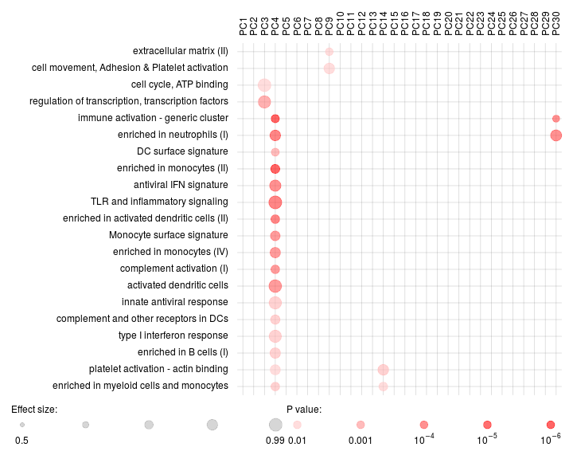

```r
tmodPanelPlot(x)
```

However, we might want to ask, for each module, how many of the genes in that module have a negative, and how many have a positive weight? We can use the function tmodDecideTests for that. For each principal component shown, we want to know how many genes have very large (in absolute terms) weights – we can use the “lfc” parameter of tmodDecideTests for that. We define here “large” as being in the top 25% of all weights in the given component. For this, we need first to calculate the 3rd quartile (top 25% threshold). We will show only 10 components:

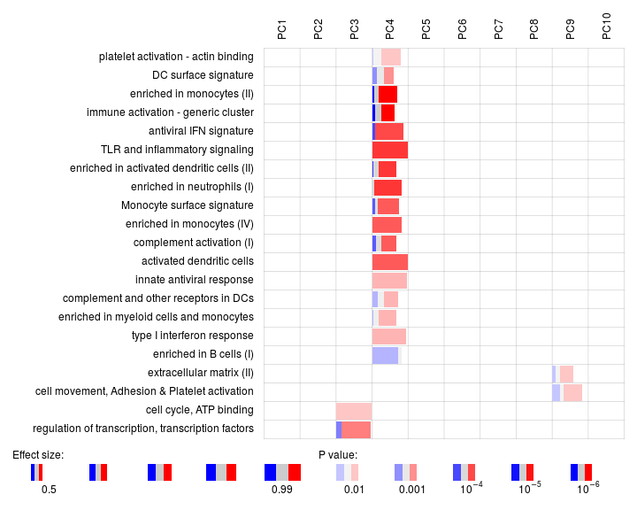

```r
qfnc <- function(r) quantile(r, 0.75)
qqs <- apply(pca$rotation[,1:10], 2, qfnc)
pie <- tmodDecideTests(gs, lfc=pca$rotation[,1:10], lfc.thr=qqs)
tmodPanelPlot(x[1:10], pie=pie,
  pie.style="rug", grid="between")
```

## PCA and tag clouds

For another way of visualizing enrichment, we can use the tagcloud package [@tagcloud]. P-Values will be represented by the size of the tags, while AUC – which is a proxy for the effect size – will be shown by the color of the tag, from grey (AUC=0.5, random) to black (1):

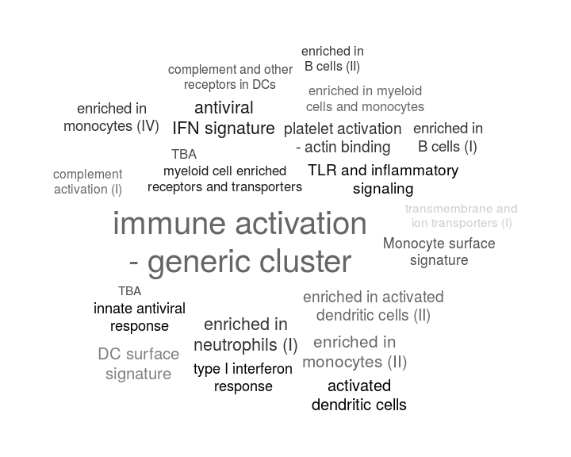

```r
library(tagcloud)
w <- -log10(res$P.Value)
c <- smoothPalette(res$AUC, min=0.5)
tags <- strmultline(res$Title)
tagcloud(tags, weights=w, col=c)
```

We can now annotate the PCA axes using the tag clouds; however, see below for a shortcut in tmod.

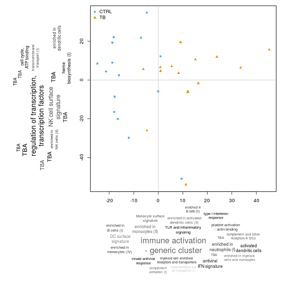

```r
par(mar=c(1,1,1,1))
o3 <- order(abs(pca$rotation[,3]), decreasing=TRUE)
l3 <- Egambia$GENE_SYMBOL[o3]
res3 <- tmodUtest(l3)
layout(matrix(c(3,1,0,2),2,2,byrow=TRUE),
  widths=c(0.3, 0.7), heights=c(0.7, 0.3))
# note -- PC4 is now x axis!!
l<-pca2d(pca, group=group, components=4:3,
  palette=mypal)
cols <- as.character(l$colors)
legend("topleft",
  as.character(l$groups),
  pch=l$shapes,
  col=cols, bty="n")
tagcloud(tags, weights=w, col=c, fvert= 0)
tagcloud(strmultline(res3$Title),
  weights=-log10(res3$P.Value),
  col=smoothPalette(res3$AUC, min=0.5),
  fvert=1)
```

As mentioned previously, there is a way of doing it all with tmod much more quickly. Note that `plot.params` are just parameters which will be passed to the pca2d function.

```
##
## Legend:
## -------------------------
##   group:   color,   shape
## -------------------------
##    CTRL: #56B4E9,      16
##      TB: #E69F00,      17
```

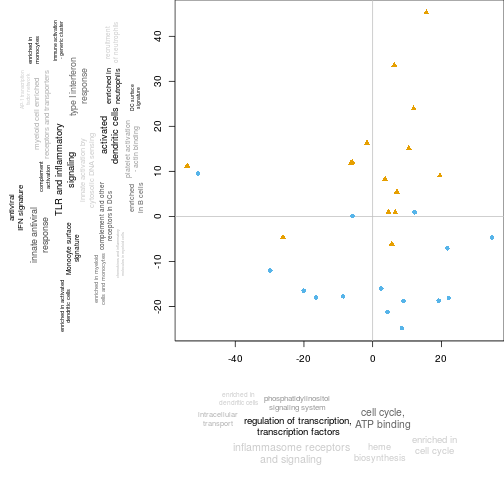

```r
tmodPCA(pca,
  genes=Egambia$GENE_SYMBOL,
  components=3:4,
  plot.params=list(group=group,
  palette=mypal
  ))
```

# Permutation tests

The GSEA approach [@subramanian2005gene] is based on similar premises as the other approaches described here. In principle, GSEA is a combination of an arbitrary scoring of a sorted list of genes and a permutation test. Although the GSEA approach has been criticized from statistical standpoint [@damian2004statistical], it remains one of the most popular tools to analyze gene sets amongst biologists. In the following, it will be shown how to use a permutation-based test with tmod.

A permutation test is based on a simple principle. The labels of observations (that is, their group assignments) are permutated and a statistic \(s_i\) is calculated for each \(i\)-th permutation. Then, the same statistic \(s_o\) is calculated for the original data set. The proportion of the permutated sets that yielded a statistic \(s_i\) equal to or higher than \(s_o\) is the p-value for a statistical hypothesis test.

First, we will set up a function that creates a permutation of the Egambia data set and repeats the limma procedure for this permutation, returning the ordering of the genes.

```r
permset <- function(data, design) {
  require(limma)
  data <- data[, sample(1:ncol(data)) ]
  fit  <- eBayes(lmFit(data, design))
  tt   <- topTable(fit, coef=2, number=Inf, sort.by="n")
  order(tt$P.Value)
}
```

```r
# same design as before
design <- cbind(Intercept=rep(1, 30),
  TB=rep(c(0,1), each= 15))
E      <- as.matrix(Egambia[,-c(1:3)])
N      <- 250  # small number for the sake of example
set.seed(54321)
perms  <- sapply(1:N, function(x) permset(E, design))
pauc   <- tmodAUC(Egambia$GENE_SYMBOL, perms)
dim(perms)
```

```
## [1] 5547  250
```

We can now calculate the true values of the AUC for each module and compare them to the results of the permutation. The parameters “order.by” and “qval” ensure that we will calculate the values for all the modules (even those without any genes in our gene list!) and in the same order as in the perms variable.

```r
fit <- eBayes(lmFit(E, design))
tt  <- topTable(fit, coef=2, number=Inf,
  genelist=Egambia[,1:3])
res <- tmodCERNOtest(tt$GENE_SYMBOL, qval=Inf, order.by="n")
all(res$ID == rownames(perms))
```

```
## [1] TRUE
```

```r
fnsum <- function(m) sum(pauc[m,] >= res[m,"AUC"])
sums <- sapply(res$ID, fnsum)
res$perm.P.Val <- sums / N
res$perm.P.Val.adj <- p.adjust(res$perm.P.Val)
res <- res[order(res$AUC, decreasing=T),]
head(res[order(res$perm.P.Val),
  c("ID", "Title", "AUC", "adj.P.Val", "perm.P.Val.adj") ])
```

```
##              ID                          Title       AUC    adj.P.Val
## LI.M16   LI.M16 TLR and inflammatory signaling 0.9790500 7.192190e-05
## LI.M59   LI.M59     CCR1, 7 and cell signaling 0.9771973 5.751429e-02
## LI.M67   LI.M67      activated dendritic cells 0.9714730 8.363690e-05
## LI.M150 LI.M150      innate antiviral response 0.9498859 9.956972e-03
## LI.M127 LI.M127     type I interferon response 0.9455715 1.163487e-02
## LI.S4     LI.S4     Monocyte surface signature 0.8974252 1.852319e-06
##         perm.P.Val.adj
## LI.M16               0
## LI.M59               0
## LI.M67               0
## LI.M150              0
## LI.M127              0
## LI.S4                0
```

Although the results are based on a small number of permutations, the results are nonetheless strikingly similar. For more permutations, they improve further. The table below is a result of calculating 100,000 permutations.

```
ID        Title                                            AUC        adj.P.Val
LI.M37.0               immune activation - generic cluster 0.7462103  0.00000
LI.M11.0                        enriched in monocytes (II) 0.7766542  0.00000
LI.M112.0                        complement activation (I) 0.8455773  0.00000
LI.M37.1                       enriched in neutrophils (I) 0.8703781  0.00000
LI.M105                                                TBA 0.8949512  0.00000
LI.S4                           Monocyte surface signature 0.8974252  0.00000
LI.M150                          innate antiviral response 0.9498859  0.00000
LI.M67                           activated dendritic cells 0.9714730  0.00000
LI.M16                      TLR and inflammatory signaling 0.9790500  0.00000
LI.M118.0                       enriched in monocytes (IV) 0.8774710  0.00295
LI.M75                             antiviral IFN signature 0.8927741  0.00295
LI.M127                         type I interferon response 0.9455715  0.00295
LI.S5                                 DC surface signature 0.6833387  0.02336
LI.M188                                                TBA 0.8684647  0.09894
LI.M165         enriched in activated dendritic cells (II) 0.7197180  0.11600
LI.M240                                chromosome Y linked 0.8157171  0.11849
LI.M20                   AP-1 transcription factor network 0.8763327  0.12672
LI.M81             enriched in myeloid cells and monocytes 0.7562851  0.13202
LI.M3                    regulation of signal transduction 0.7763995  0.14872
LI.M4.3   myeloid cell enriched receptors and transporters 0.8859573  0.15675
```

Unfortunately, the permutation approach has two main drawbacks. Firstly, it requires a sufficient number of samples – for example, with three samples in each group there are only \(6!=720\) possible permutations. Secondly, the computational load is substantial.

# Accessing the tmod data

The `tmod` package stores its data in two data frames and two lists. This object is contained in a list called `tmod`, which is loaded with `data("tmod")`. The names mimick the various environments from Annotation.dbi packages, but currently the objects are just two lists and two data frames.

- **tmod$MODULES** is a data frame which contains general module information as defined in the supplementary materials for Li et al. [@li2013molecular] and Chaussabel et al. [@chaussabel2008modular]
- **tmod$GENES** is a data frame which contains general gene information, including columns with HGNC (“primary”), as well as ENTREZ and REFSEQ identifiers.
- **tmod$MODULES2GENES** is a list with module IDs (same as in the “ID” column of tmod$MODULES) as names. Every element of the list is a character vector with IDs (“primary” column of tmod$GENES) of the genes which are included in this module.
- **tmod$GENES2MODULES** is a list with gene IDs (same as in the “primary” column of tmod$GENES) as names. Every element of the list is a character vector with IDs of the modules in which the gene is found.

Using these variables, one can apply any other tool for the analysis of enriched module sets available, for example, the `geneSetTest` function from the limma package (Smyth et al. [@limma]). We will first run `tmodUtest` setting the `qval` to `Inf` to get p-values for all modules. Then, we apply the `geneSetTest` function to each module:

```r
data(tmod)
res <- tmodUtest(tt$GENE_SYMBOL, qval=Inf)
gstest <- function(x) {
  sel <- tt$GENE_SYMBOL %in% tmod$MODULES2GENES[[x]]
  geneSetTest(sel, tt$logFC)
}
gst <- sapply(res$ID, gstest)
```

Are the results of both statistical approaches similar? `tmod` uses a very simple statistical test. The approach from `geneSetTest` is more complex, but similar in principle.

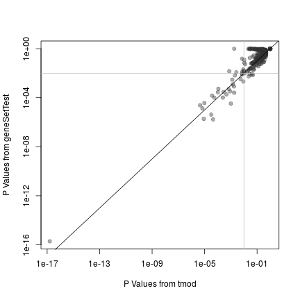

```r
plot(res$P.Value, gst,
  log="xy", pch=19,
  col="#33333366",
  xlab="P Values from tmod",
  ylab="P Values from geneSetTest")
abline(0,1)
abline(h=0.01, col="grey")
abline(v=0.01, col="grey")
```

On the plot above, the p-values from `tmod` are plotted against the p-values from `geneSetTest`. As you can see, in this particular example, both methods give very similar results.

# Using and creating custom sets of modules

It is possible to use any kind of arbitrary or custom gene set definitions. These custom definition of gene sets takes form of a list which is then provided as the `mset` parameter to the test functions. The list in question must have the following members:

- **MODULES** A data frame which contains at least the columns “ID” and “Title”. The IDs must correspond to the names of MODULES2GENES.
- **GENES** A data frame which contains at least the column “ID”. The gene IDs must correspond to the gene IDs used in MODULES2GENES.
- **MODULES2GENES** A list. The names of the list are the IDs from the MODULES data frame. The items in the list are character vectors with names of the genes that are associated with each module.

Here is a minimal definition of such a set:

```r
mymset <- new("tmod", list(
  MODULES=data.frame(ID=c("A", "B"),
                       Title=c("A title",
                                      "B title")),
  GENES=data.frame(ID=c( "G1", "G2", "G3", "G4" )),
  MODULES2GENES=list(
    A=c("G1", "G2"),
    B=c("G3", "G4")))
)
mymset
```

```
## An object of class "tmod"
##  2 modules, 4 genes
```

Whether the gene IDs are Entrez, or something else entirely does not matter, as long as they matched the provided input to the test functions.

## MSigDB

The MSigDB database from the Broad institute is an interesting collection of gene sets (actually, multiple collections). Unfortunately, MSigDB cannot be distributed or even accessed without a free registration, which imposes a heavy limination on third party tools such as tmod. Use the following guide to download and parse the database such that you can use it with R and tmod.

First, you will need to download the MSigDB in XML format<sup>[Note</sup> that even if you register with MSig, it is not possible to download the database directly from R in the XML format.]. This file can be accessed at the URL http://www.broadinstitute.org/gsea/msigdb/download_file.jsp?filePath=/resources/msigdb/5.0/msigdb_v5.0.xml – follow the link, register and log in, and save the file on your disk (roughly 65MB).

Importing MSigDB is easy – tmod has a function specifically for that purpose. Once you have downloaded the MSigDB file, you can create the tmod-compatible R object with one command<sup>[MSigDB</sup> gene sets can be also downloaded as “GMT” files. This format contains less information and is therefore less usable.]. However, the tmod function tmodImportMsigDB() can also use this format, look up the manual page:

```r
msig <- tmodImportMSigDB("msigdb_v5.0.xml")
msig
```

```
## An object of class "tmod"
##   8430 modules, 32233 genes
```

That's it – now you can use the full MSigDB for enrichment tests:

```r
res <- tmodCERNOtest(tt$GENE_SYMBOL, mset=msig )
head(res)
```

```
##          ID                                          Title
## M3408 M3408          GSE1432 ctrl vs ifng 24h microglia dn
## M3010 M3010                           Hecker ifnb1 targets
## M3286 M3286    GSE13485 ctrl vs day3 yf17d vaccine pbmc dn
## M3288 M3288    GSE13485 ctrl vs day7 yf17d vaccine pbmc dn
## M3311 M3311 GSE13485 pre vs post yf17d vaccination pbmc dn
## M3347 M3347                GSE14000 unstim vs 4h lps dc dn
##          cerno N1       AUC      cES      P.Value
## M3408 239.0983 39 0.8014227 3.065363 2.967858e-18
## M3010 244.1219 43 0.8459807 2.838626 4.555892e-17
## M3286 247.0915 45 0.7293732 2.745461 1.408943e-16
## M3288 272.2570 54 0.7222067 2.520898 3.626792e-16
## M3311 229.4948 41 0.7272625 2.798718 6.715323e-16
## M3347 272.0698 55 0.7334883 2.473362 9.792737e-16
##          adj.P.Val
## M3408 2.501904e-14
## M3010 1.920308e-13
## M3286 3.959129e-13
## M3288 7.643464e-13
## M3311 1.132204e-12
## M3347 1.375880e-12
```

The results are quite typical for MSigDB, which is quite abundant with similar or overlapping gene sets. As the first results, we see, again, interferon response, as well as sets of genes which are significantly upregulated after yellow fever vaccination – and which are also interferon related. We might want to limit our analysis only to the 50 “hallmark” module categories:

```r
sel <- msig$MODULES$Category == "H"
tmodCERNOtest(tt$GENE_SYMBOL, mset=msig[sel] )
```

```
##          ID                                      Title
## M5913 M5913         Hallmark interferon gamma response
## M5921 M5921                        Hallmark complement
## M5911 M5911         Hallmark interferon alpha response
## M5946 M5946                       Hallmark coagulation
## M5890 M5890           Hallmark tnfa signaling via nfkb
## M5930 M5930 Hallmark epithelial mesenchymal transition
## M5932 M5932             Hallmark inflammatory response
## M5953 M5953                 Hallmark kras signaling up
## M5892 M5892           Hallmark cholesterol homeostasis
##           cerno N1       AUC      cES      P.Value
## M5913 221.68317 41 0.7786936 2.703453 8.505170e-15
## M5921 217.81028 56 0.6979148 1.944735 8.607634e-09
## M5911 108.39559 20 0.7563566 2.709890 3.192325e-08
## M5946 179.24580 50 0.6779481 1.792458 1.966824e-06
## M5890 148.95123 47 0.6484665 1.584588 2.657694e-04
## M5930 212.53461 73 0.6371808 1.455717 2.701053e-04
## M5932 184.53035 62 0.6206393 1.488148 3.457724e-04
## M5953 221.76208 82 0.6046637 1.352208 1.790956e-03
## M5892  49.14641 14 0.6138968 1.755229 8.040562e-03
##          adj.P.Val
## M5913 4.252585e-13
## M5921 2.151909e-07
## M5911 5.320542e-07
## M5946 2.458530e-05
## M5890 2.250878e-03
## M5930 2.250878e-03
## M5932 2.469803e-03
## M5953 1.119347e-02
## M5892 4.466979e-02
```

We see both – the prominent interferon response and the complement activation. Also, in addition, TNF-\(\alpha\) signalling via NF-\(\kappa\beta\).

## Manual creation of tmod module objects: MSigDB

For the purposes of an example, the code below shows how to parse the XML MSigDB file using the R package XML. Essentially, this is the same code that tmodImportMsigDB is using:

```r
library(XML)
foo  <- xmlParse( "/home/january/Projects/R/pulemodule/vignette/msigdb_v5.0.xml" )
foo2 <- xmlToList(foo)
```

There are over 10,000 “gene sets” (equivalent to modules in tmod) defined. Each member of foo2 is a named character vector:

```r
path1 <- foo2[[1]]
class(path1)
```

```
## [1] "character"
```

```r
names(path1)
```

```
##  [1] "STANDARD_NAME"        "SYSTEMATIC_NAME"
##  [3] "HISTORICAL_NAMES"     "ORGANISM"
##  [5] "PMID"                 "AUTHORS"
##  [7] "GEOID"                "EXACT_SOURCE"
##  [9] "GENESET_LISTING_URL"  "EXTERNAL_DETAILS_URL"
## [11] "CHIP"                 "CATEGORY_CODE"
## [13] "SUB_CATEGORY_CODE"    "CONTRIBUTOR"
## [15] "CONTRIBUTOR_ORG"      "DESCRIPTION_BRIEF"
## [17] "DESCRIPTION_FULL"     "TAGS"
## [19] "MEMBERS"              "MEMBERS_SYMBOLIZED"
## [21] "MEMBERS_EZID"         "MEMBERS_MAPPING"
## [23] "FOUNDER_NAMES"        "REFINEMENT_DATASETS"
## [25] "VALIDATION_DATASETS"
```

For our example analysis, we will use only human gene sets. We further need to make sure there are no NULLs in the list.

```r
orgs <- sapply(foo2, function(x) x["ORGANISM"])
unique(orgs)

foo3 <- foo2[ orgs == "Homo sapiens" ]
foo3 <- foo3[ ! sapply(foo3, is.null) ]
```

Next, construct the MODULES data frame. We will use four named fields for each vector, which contain the ID (systematic name), description, category and subcategory:

```r
msig <- list()

msig$MODULES <- t(sapply(foo3,
  function(x)
    x[ c("SYSTEMATIC_NAME", "STANDARD_NAME", "CATEGORY_CODE", "SUBCATEGORY_CODE") ]))
colnames(msig$MODULES) <- c( "ID", "Title", "Category", "Subcategory" )
rownames(msig$MODULES) <- msig$MODULES[,"ID"]
msig$MODULES <- data.frame(msig$MODULES, stringsAsFactors=FALSE)
```

Then, we create the modules to genes mapping and the GENES data frame. For this, we use the `MEMBERS_SYMBOLIZED` field, which is a comma separated list of gene symbols belonging to a particular module:

```r
msig$MODULES2GENES <- lapply(foo3,
  function(x) strsplit( x["MEMBERS_SYMBOLIZED"], "," )[[1]])
names(msig$MODULES2GENES) <- msig$MODULES$ID

msig$GENES <- data.frame( ID=unique(unlist(msig$MODULES2GENES)))
msig <- new("tmod", msig)
```

From now on, you can use msig with tmod.

## Manual creation of tmod module sets: Wikipathways

Below is an example of how to use the pathway definitions from WikiPathways<sup>[http://www.wikipathways.org/].</sup> First, we download the data (human pathways) and clean it up:

```r
human <- tempfile()
download.file(
  "http://www.wikipathways.org//wpi/batchDownload.php?species=Homo%20sapiens&fileType=txt",
  destfile=human, mode="wb")
files <- unzip(human, list=T)

files$ID    <- gsub( ".*_(WP[0-9]*)_.*", "\\1", files$Name )
files$Title <- gsub( "(.*)_WP[0-9]*_.*", "\\1", files$Name )
```

Since each pathway is in a separate file in the zip archive we downloaded, we have to read each file separately. Below, we create a list, `p2GENES`, which maps the modules to the corresponding genes. To make it consistent, I decided to use gene symbols rather than the Entrez numbers (just because it makes the interpretation of results a bit easier), but actually that is not necessary: tmod does not care what gene symbols are used, as long as the mappings between genes and modules are consistent, and as long as the same identifiers are used in the lists of genes.

Furthermore, note that we filter out anything that is not an ENTREZ gene identifier. This gets rid of entities which are not genes (e.g. biochemical compounds), but also of some genes.

```r
suppressMessages(library(org.Hs.eg.db))
p2GENES <- sapply( files$Name, function(fn) {
  foo <- read.csv( unz( human,
  filename= fn ), sep="\t" )
  ids <- foo$Identifier[ foo$Identifier %in% ls( org.Hs.egSYMBOL ) ]
  unique(unlist(mget(as.character(ids), org.Hs.egSYMBOL)))
})

names(p2GENES) <- files$ID
```

p2GENES is the first of three objects that we need to create. The next one is a data frame containing module definitions. We also calculate the number of associated genes and select pathways that have at least 5 associated ENTREZ genes:

```r
pathways <- data.frame( ID=files$ID,
  Title=files$Title,
  stringsAsFactors=FALSE )
pathways$N <- sapply(p2GENES, length)
pathways$URL <-
  paste0("http://www.wikipathways.org/index.php/Pathway:",
  pathways$ID )
sel <- pathways$N > 4
pathways <- pathways[ sel, ]
rownames(pathways) <- pathways$ID
```

Finally, we need a data frame containing the gene IDs<sup>[The</sup> reason why it is a data frame and not simply a vector of IDs and why it is necessary at all since it can be calculated from the module to gene mapping: it is faster and allows for more than just one gene symbol.] and we are good to go: we can build the list that will be the value of the mset parameter:

```r
GENES <- data.frame( ID=unique(unlist(p2GENES)),
  stringsAsFactors=FALSE)

Hspaths <- list( MODULES=pathways,
      MODULES2GENES=p2GENES,
      GENES=GENES )
Hspaths <- new("tmod", Hspaths)
```

We can now use the tmodCERNOtest to see whether it works:

```r
tmodCERNOtest(tt$GENE_SYMBOL, mset=Hspaths)
```

```
##          ID                                       Title     cerno N1
## WP558 WP558      Hs_Complement_and_Coagulation_Cascades 107.73082 28
## WP545 WP545 Hs_Complement_Activation,_Classical_Pathway  45.65536  9
##             AUC      cES      P.Value  adj.P.Val
## WP558 0.6418746 1.923765 4.008176e-05 0.00865766
## WP545 0.7465689 2.536409 3.330196e-04 0.03596611
```

Nice – the complement pathway was also found before, when using the default data set. Unfortunately, we don't see anything else: WikiPathways are more oriented on metabolic pathways, while the blood transcriptional modules are particularly good for analyzing immune responses. However, if we were to test a specific hypothesis, we would select modules related to interferon response:

```r
sel <- grep( "Interferon",
  Hspaths$MODULES$Title, ignore.case=T )
tmodCERNOtest(tt$GENE_SYMBOL, mset=Hspaths,
  modules=Hspaths$MODULES$ID[sel])
```

```
##          ID                                  Title   cerno N1       AUC
## WP619 WP619 Hs_Type_II_interferon_signaling_(IFNG) 42.1566  9 0.7050031
##            cES     P.Value   adj.P.Val
## WP619 2.342033 0.001051527 0.003154582
```

Since the number of tests is lower, the type-II interferon signalling is now significant.